# Slidify_BrainR

GeorgiiC

29 September 2018

## Introduction

This app uses the r package *brainR* to display an interactive 3D brain. This app was originally build to create an easy to use environment to display changes in the pattern of brain activations (for simplicity this is not included in this demo app).

## Functionality

The functionality of this app includes:

- Interactive Movement of the brain by simply clicking on it.
- Changing the transparency values of the displayed 3D brain by using the slider option
- Changing the color of the displayed 3D brain by specifying a color from the drop-down menu.
- NOTE: the value set for color and transparency interact with each other.

## Changing transparency

You can change the transparency using the slider. For example choosing a value of 100 would result in an **not** transparent brain, looking like this:

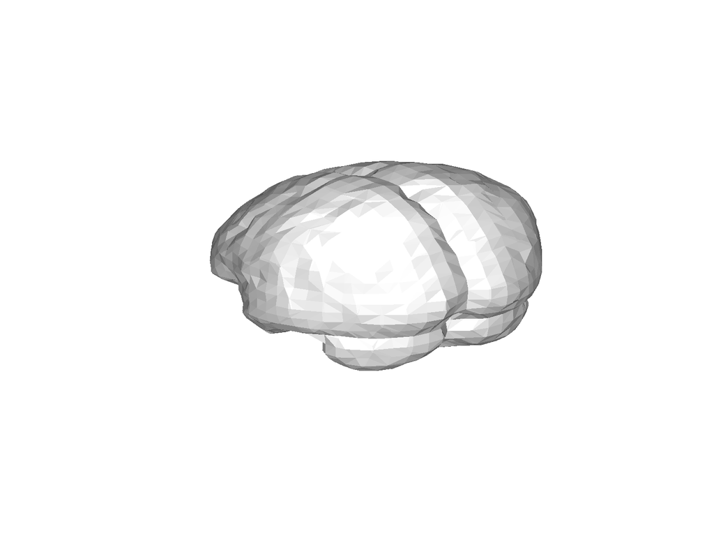

A value of 30 would result in a transparent brain, looking like this:

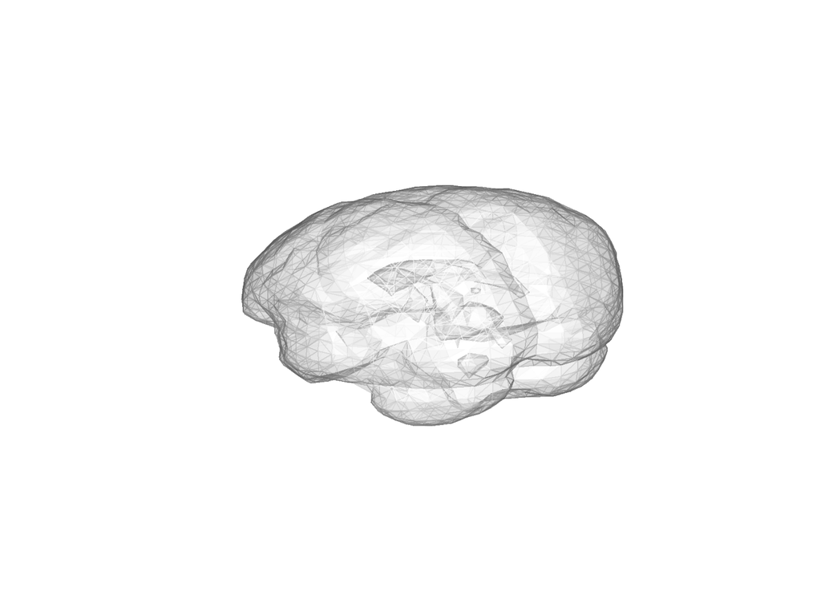

## Changing color

You can change the color of the brain to a set of predefined colors (yellow, red, blue, white). Note that the transparency and color values interact with each other, thus it is possible to have a brain being colored and transparent at the same time!

## Closing Words

Have fun playing around with the app!